# “Carry-on effect analysis with proportion of steps correct on the first attempt”

Bin & Lizzy

7/12/2021

## Visualizing Performance

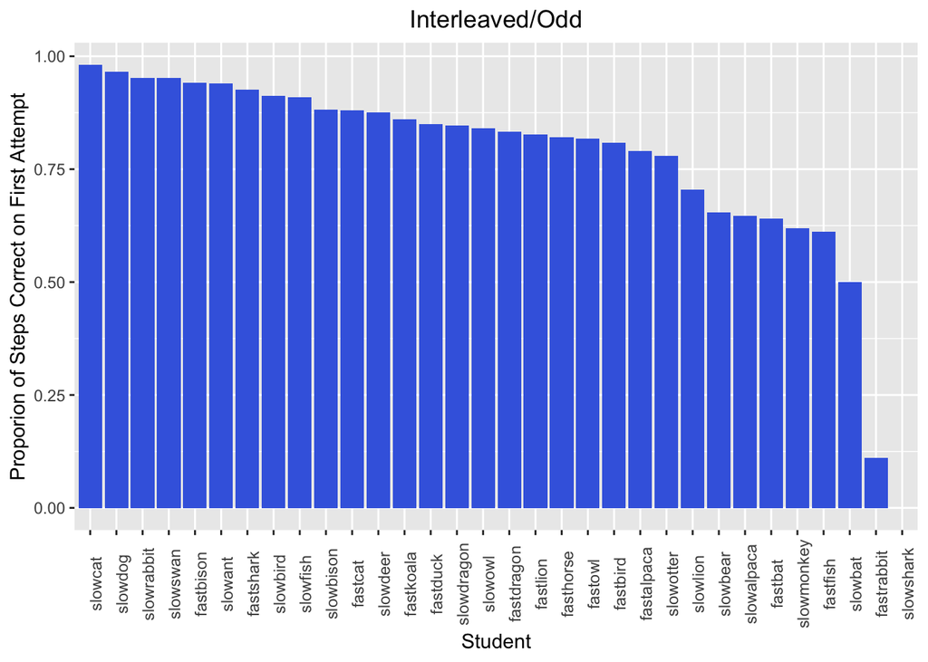

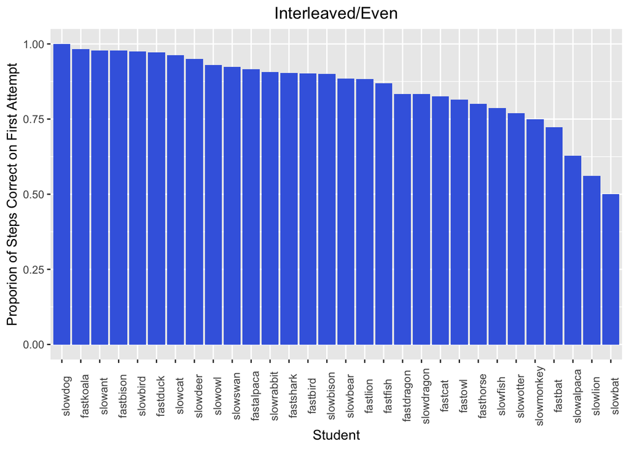

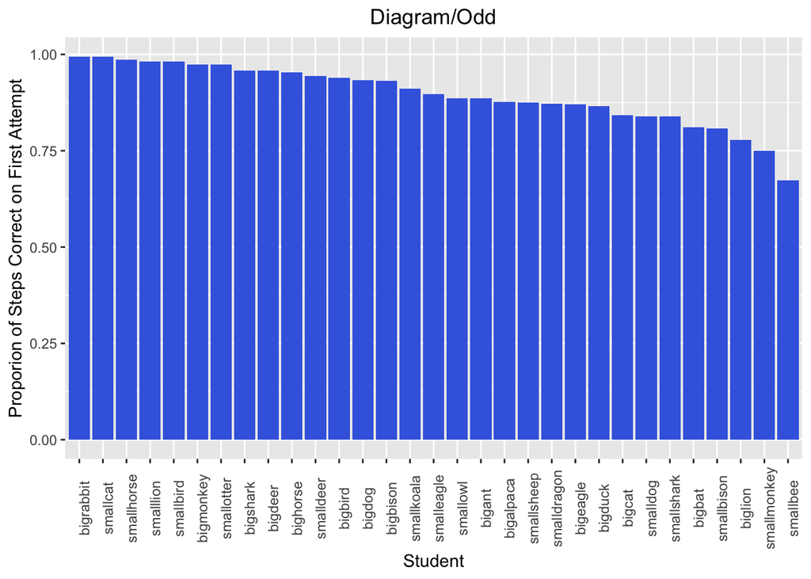

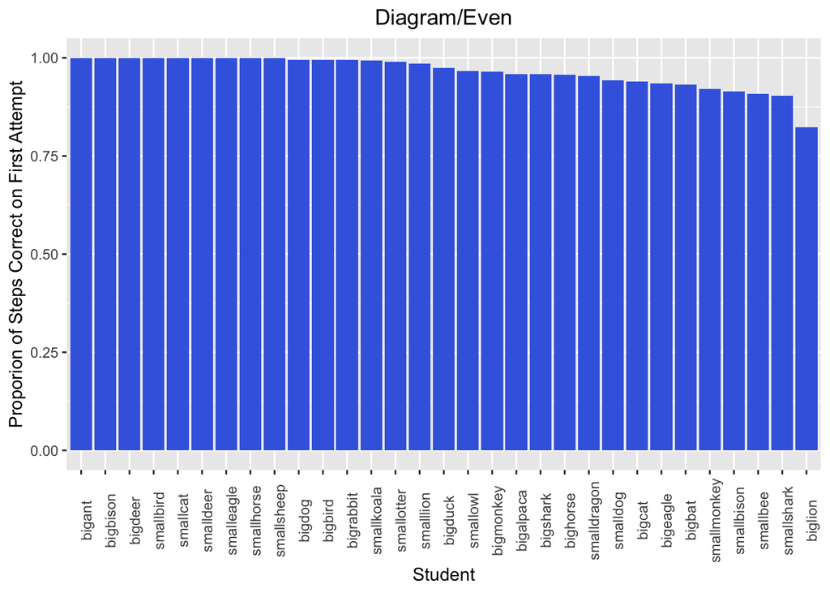

## Interleaved/Even vs. Interleaved/Odd

### Graphical Comparison

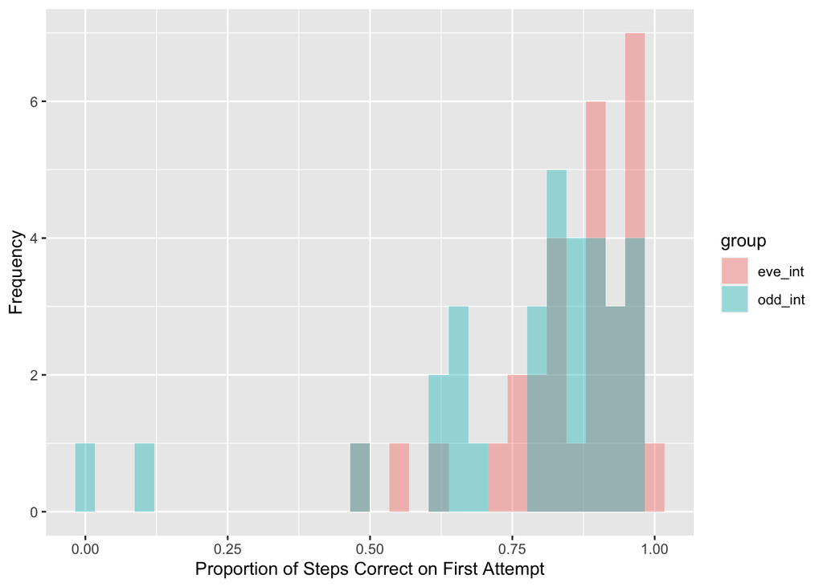

We can see that the Interleaved/Even (pink) is mostly clustered around high values of proportion of steps correct on the first try whereas Interleaved/Odd has a bit more spread and seems to be possibly centered around lower values of proportions of steps correct on the first try than that of the Interleaved/Even.

### Hypothesis Testing

Students in the Interleaved condition should do better on the even problems than the odd problems (because they learn from the odd problems)

```r
t.test(int_eve$prop_first_try, int_odd$prop_first_try, alternative = "greater")
```

```
##
##  Welch Two Sample t-test
##
## data:  int_eve$prop_first_try and int_odd$prop_first_try
## t = 1.8326, df = 49.293, p-value = 0.03646
## alternative hypothesis: true difference in means is greater than 0
## 95 percent confidence interval:
##  0.007117378         Inf
## sample estimates:
## mean of x mean of y
## 0.8547264 0.7712260
```

Students in the Interleaved condition performed significantly better on the even problems in terms of proportion of steps correct on the first try (p = .036). This suggests that students learn from the odd problems with diagrams and can apply the knowledge to similar problems without diagrams.

## Interleaved/Even vs. Diagram/Even

### Graphical Comparison

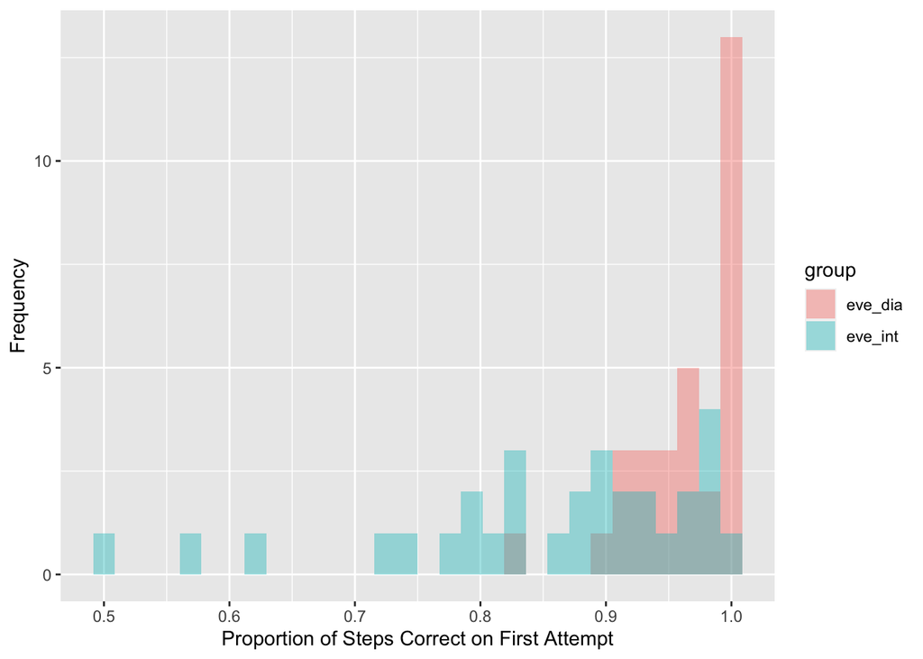

Students in the Diagrams condition seems to be doing very well on even problems. Their propotions of steps correct on the first try is generally in the .9 - 1 range and peaks at 1. Students in the Interleaved condition, however, seems to be doing much worse on the even problems.

### Hypothesis Testing

Students in both conditions should perform the same on even problems, since they should have learned the skills necessary to do the even problems from the odd problems.

```r
t.test(int_eve$prop_first_try, dia_eve$prop_first_try)
```

```
##
##  Welch Two Sample t-test
##
## data:  int_eve$prop_first_try and dia_eve$prop_first_try
## t = -4.5834, df = 35.056, p-value = 5.591e-05
## alternative hypothesis: true difference in means is not equal to 0
## 95 percent confidence interval:
##  -0.1585426 -0.0612128
## sample estimates:
## mean of x mean of y
## 0.8547264 0.9646041
```

Students in the Diagrams condition performed significantly better on the even problems than the students in the Interleaved condition (p << .001). This suggests that either the students applies the knowledge learned from odd diagram problems better to similar problems with diagrams or that students in the Diagrams condition are more knowledgeable than students in the Interleaved condition in general.

## Interleaved/Odd vs. Diagram/Odd

### Graphical Comparison

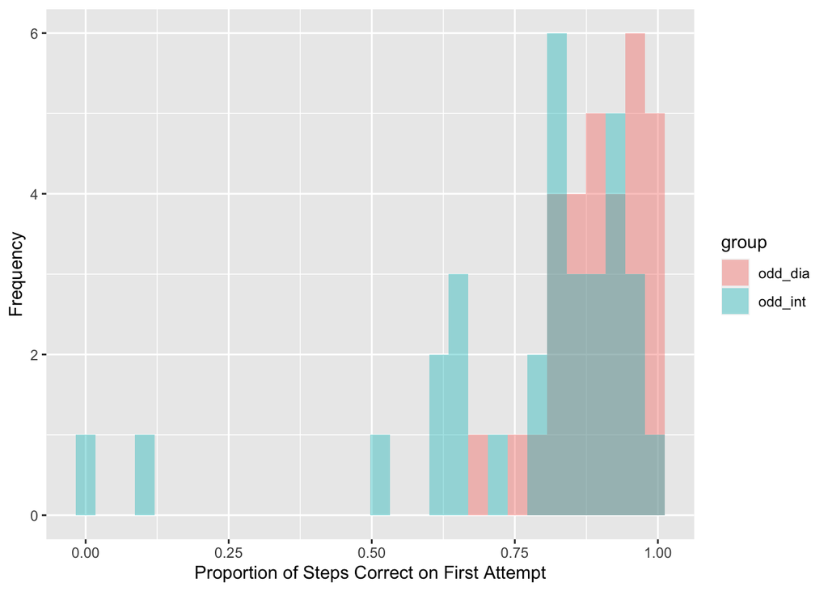

### Hypothesis Testing

Students in both conditions should perform the same on odd problems because they are all encountering this kind of problems for the first time.

```r
t.test(int_odd$prop_first_try, dia_odd$prop_first_try)
```

```
##
##  Welch Two Sample t-test
##
## data:  int_odd$prop_first_try and dia_odd$prop_first_try
## t = -2.9845, df = 38.766, p-value = 0.004898
## alternative hypothesis: true difference in means is not equal to 0
## 95 percent confidence interval:
##  -0.20977037 -0.04027286
## sample estimates:
## mean of x mean of y
## 0.7712260 0.8962477
```

Students in the Diagram condition does significantly better on the odd problems than students in the Interleaved condition (p = .005). This suggests that tape diagrams are useful in guiding students to solve equations. Though this could also mean that students in the Diagram condition are more knowledgeable to begin with.

## Symbolic steps only

### Interleaved/Even vs. Interleaved/Odd

```r
t.test(int_eve$prop_first_try_sym, int_odd$prop_first_try_sym, alternative = "greater")
```

```
##
##  Welch Two Sample t-test
##
## data:  int_eve$prop_first_try_sym and int_odd$prop_first_try_sym
## t = 2.7642, df = 46.181, p-value = 0.004085
## alternative hypothesis: true difference in means is greater than 0
## 95 percent confidence interval:
##  0.05402459        Inf
## sample estimates:
## mean of x mean of y
## 0.8547264 0.7171764
```

### Interleaved/Even vs. Diagram/Even

```r
t.test(int_eve$prop_first_try_sym, dia_eve$prop_first_try_sym)
```

```
##
##  Welch Two Sample t-test
##
## data:  int_eve$prop_first_try_sym and dia_eve$prop_first_try_sym
## t = -3.9474, df = 40.74, p-value = 0.0003052
## alternative hypothesis: true difference in means is not equal to 0
## 95 percent confidence interval:
##  -0.14969393 -0.04835161
## sample estimates:
## mean of x mean of y
## 0.8547264 0.9537492
```

### Interleaved/Odd vs. Diagram/Odd

```r
t.test(int_odd$prop_first_try_sym, dia_odd$prop_first_try_sym)
```

```
##
##  Welch Two Sample t-test
##
## data:  int_odd$prop_first_try_sym and dia_odd$prop_first_try_sym
## t = -2.957, df = 42.884, p-value = 0.005035
## alternative hypothesis: true difference in means is not equal to 0
## 95 percent confidence interval:
##  -0.24101899 -0.04555796
## sample estimates:
## mean of x mean of y
## 0.7171764 0.8604648
```

## Testing for pretest and parity main effect and interaction for the Interleaved condition

```r
lin_mod <- lm(prop_first_try ~ pretest * group,
              data = dfff)
summary(lin_mod)
```

```
##
## Call:
## lm(formula = prop_first_try ~ pretest * group, data = dfff)
##
## Residuals:
##      Min       1Q   Median       3Q      Max
## -0.67363 -0.03118  0.02653  0.07006  0.29189
##
## Coefficients:
##                      Estimate Std. Error t value Pr(>|t|)
## (Intercept)           0.72213    0.05867  12.308   <2e-16 ***
## pretest               0.06742    0.02581   2.612   0.0114 *
## groupodd_int         -0.04850    0.07102  -0.683   0.4973
## pretest:groupodd_int  0.02722    0.03753   0.725   0.4713
## ---
## Signif. codes:  0 '***' 0.001 '**' 0.01 '*' 0.05 '.' 0.1 ' ' 1
##
## Residual standard error: 0.1611 on 58 degrees of freedom
## Multiple R-squared:  0.2843, Adjusted R-squared:  0.2473
## F-statistic: 7.682 on 3 and 58 DF,  p-value: 0.0002088
```

```r
lin_mod_sym <- lm(prop_first_try_sym ~ pretest * group,
              data = dfff)
summary(lin_mod_sym)
```

```
##
## Call:
## lm(formula = prop_first_try_sym ~ pretest * group, data = dfff)
##
## Residuals:
##      Min       1Q   Median       3Q      Max
## -0.60224 -0.04310  0.02561  0.07947  0.35125
##
## Coefficients:
##                      Estimate Std. Error t value Pr(>|t|)
## (Intercept)           0.72213    0.06382  11.316 2.61e-16 ***
## pretest               0.06742    0.02808   2.401   0.0196 *
## groupodd_int         -0.11989    0.07724  -1.552   0.1261
## pretest:groupodd_int  0.04403    0.04082   1.079   0.2853
## ---
## Signif. codes:  0 '***' 0.001 '**' 0.01 '*' 0.05 '.' 0.1 ' ' 1
##
## Residual standard error: 0.1753 on 58 degrees of freedom
## Multiple R-squared:  0.3367, Adjusted R-squared:  0.3024
## F-statistic: 9.815 on 3 and 58 DF,  p-value: 2.485e-05
```

```r
lin_mod1 <- lm(prop_first_try ~ pretest + group,
              data = dfff)
summary(lin_mod1)
```

```
##
## Call:
## lm(formula = prop_first_try ~ pretest + group, data = dfff)
##
## Residuals:
##      Min       1Q   Median       3Q      Max
## -0.68842 -0.04251  0.02579  0.06962  0.27709
##
## Coefficients:
##               Estimate Std. Error t value Pr(>|t|)
## (Intercept)   0.696814   0.046964  14.837  < 2e-16 ***
## pretest       0.080294   0.018663   4.302 6.45e-05 ***
## groupodd_int -0.008392   0.044362  -0.189    0.851
## ---
## Signif. codes:  0 '***' 0.001 '**' 0.01 '*' 0.05 '.' 0.1 ' ' 1
##
## Residual standard error: 0.1605 on 59 degrees of freedom
## Multiple R-squared:  0.2779, Adjusted R-squared:  0.2534
## F-statistic: 11.35 on 2 and 59 DF,  p-value: 6.751e-05
```

```r
lin_mod_sym1 <- lm(prop_first_try_sym ~ pretest + group,
              data = dfff)
summary(lin_mod_sym1)
```

```
##
## Call:
## lm(formula = prop_first_try_sym ~ pretest + group, data = dfff)
##
## Residuals:
##      Min       1Q   Median       3Q      Max
## -0.62617 -0.05791  0.03183  0.08902  0.32732
##
## Coefficients:
##              Estimate Std. Error t value Pr(>|t|)
## (Intercept)   0.68118    0.05136  13.263  < 2e-16 ***
## pretest       0.08825    0.02041   4.324 5.99e-05 ***
## groupodd_int -0.05500    0.04851  -1.134    0.261
## ---
## Signif. codes:  0 '***' 0.001 '**' 0.01 '*' 0.05 '.' 0.1 ' ' 1
##
## Residual standard error: 0.1755 on 59 degrees of freedom
## Multiple R-squared:  0.3234, Adjusted R-squared:  0.3005
## F-statistic:  14.1 on 2 and 59 DF,  p-value: 9.866e-06
```

## Performance on specific KCs in the Interleaved condition

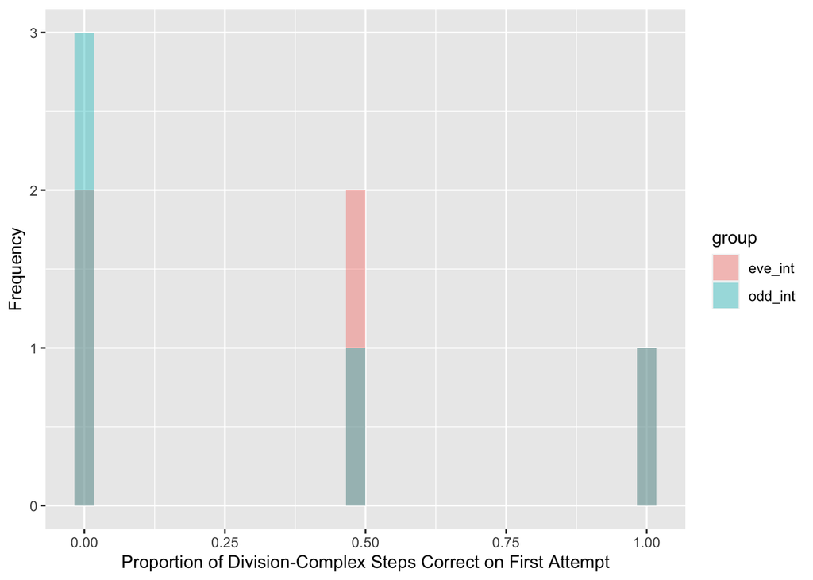

```r
t.test(na.omit(int_eve$division_complex), na.omit(int_odd$division_complex), alternative = "greater")
```

```
##
##  Welch Two Sample t-test
##
## data:  na.omit(int_eve$division_complex) and na.omit(int_odd$division_complex)
## t = 0.36515, df = 7.9646, p-value = 0.3623
## alternative hypothesis: true difference in means is greater than 0
## 95 percent confidence interval:
##  -0.4095518        Inf
## sample estimates:
## mean of x mean of y
##       0.4       0.3
```

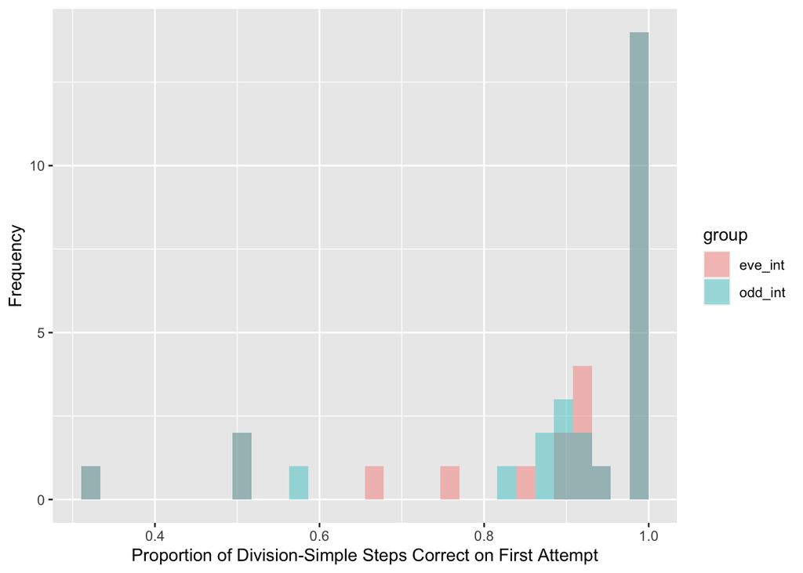

```r
t.test(na.omit(int_eve$division_simple), na.omit(int_odd$division_simple), alternative = "greater")
```

```
##
##  Welch Two Sample t-test
##
## data:  na.omit(int_eve$division_simple) and na.omit(int_odd$division_simple)
## t = 0.018754, df = 51.979, p-value = 0.4926
## alternative hypothesis: true difference in means is greater than 0
## 95 percent confidence interval:
##  -0.082778       Inf
## sample estimates:
## mean of x mean of y
## 0.8878802 0.8869427
```

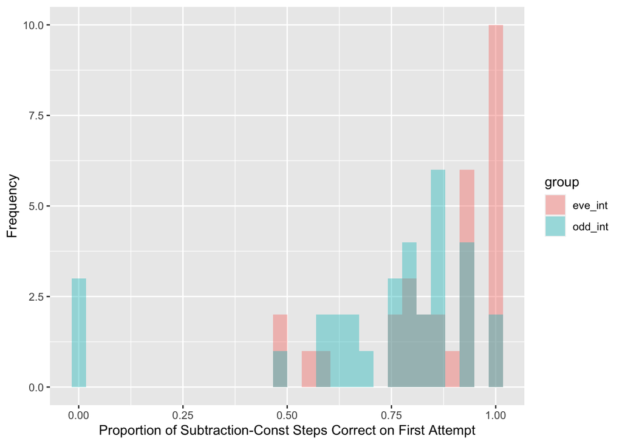

```r
t.test(na.omit(int_eve$subtraction_const), na.omit(int_odd$subtraction_const), alternative = "greater")
```

```
##
##  Welch Two Sample t-test
##
## data:  na.omit(int_eve$subtraction_const) and na.omit(int_odd$subtraction_const)
## t = 2.6791, df = 51.388, p-value = 0.004946
## alternative hypothesis: true difference in means is greater than 0
## 95 percent confidence interval:
##  0.05524441        Inf
## sample estimates:
## mean of x mean of y
## 0.8607844 0.7133754
```

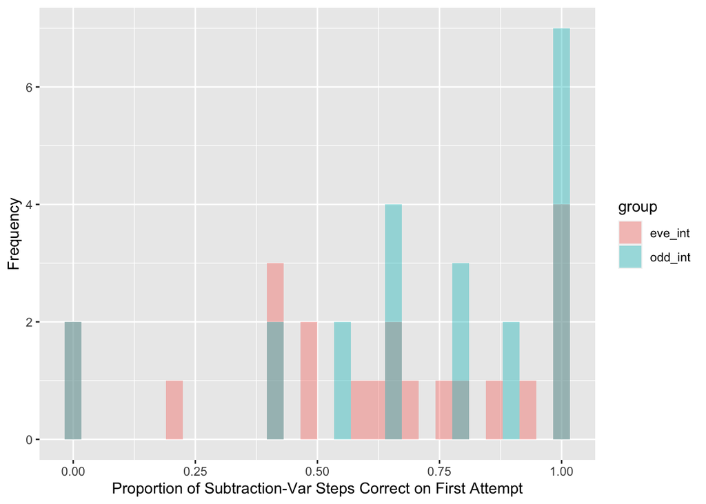

```r
t.test(na.omit(int_eve$subtraction_var), na.omit(int_odd$subtraction_var), alternative = "greater")
```

```
##
##  Welch Two Sample t-test
##
## data:  na.omit(int_eve$subtraction_var) and na.omit(int_odd$subtraction_var)
## t = -1.0206, df = 40.86, p-value = 0.8433
## alternative hypothesis: true difference in means is greater than 0
## 95 percent confidence interval:
##  -0.2522614        Inf
## sample estimates:
## mean of x mean of y
## 0.6213937 0.7166208
```